# CIND 123 - Data Analytics: Basic Methods

# Assignment 1 (10%)

## Princeton Dcunha

### DHA 501150458 ## Instructions This is an R Markdown document. Markdown is a simple formatting syntax for authoring HTML, PDF, and MS Word documents. Review this website for more details on using R Markdown http://rmarkdown.rstudio.com. Use RStudio for this assignment. Complete the assignment by inserting your R code wherever you see the string “#INSERT YOUR ANSWER HERE”. When you click the **Knit** button, a document (PDF, Word, or HTML format) will be generated that includes both the assignment content as well as the output of any embedded R code chunks. Submit **both** the rmd and generated output files. Failing to submit both files will be subject to mark deduction. Use `seq()` to create the vector $(3,5\ldots,29)$. seq(3, 30, 2) ## [1] 3 5 7 9 11 13 15 17 19 21 23 25 27 29 seq(3, 29, 2) ## [1] 3 5 7 9 11 13 15 17 19 21 23 25 27 29 Create and print a vector `x` with all integers 1-100, and a vector `y` with even integer in the same range. Hint: use `seq()`function. Calculate the difference in lengths of the vectors `x` and `y`. Hint: use length() (8 points) x <- seq(1,100) x ## [1] 1 2 3 4 5 6 7 8 9 10 11 12 13 14 15 16 17 18 ## [19] 19 20 21 22 23 24 25 26 27 28 29 30 31 32 33 34 35 36 ## [37] 37 38 39 40 41 42 43 44 45 46 47 48 49 50 51 52 53 54 ## [55] 55 56 57 58 59 60 61 62 63 64 65 66 67 68 69 70 71 72 ## [73] 73 74 75 76 77 78 79 80 81 82 83 84 85 86 87 88 89 90 ## [91] 91 92 93 94 95 96 97 98 99 100 y <- seq(2,100,2) y ## [1] 2 4 6 8 10 12 14 16 18 20 22 24 26 28 30 32 34 36 38 ## [20] 40 42 44 46 48 50 52 54 56 58 60 62 64 66 68 70 72 74 76 ## [39] 78 80 82 84 86 88 90 92 94 96 98 100 length(x)-length(y) ## [1] 50 Create a new vector, “x_square”, with the square of elements at indices 1, 3, 6, 7, 10, 15, 20, 23, 24, and 29 from the variable “x”. Hint: Use indexing rather than a for loop. Calculate the mean and median of the FIRST five values from x_square. (8 points) x_square <- x[c(1,3,6,7,10,15,20,23,24,29)]^2 x_square ## [1] 1 9 36 49 100 225 400 529 576 841 mean(x_square[1:5]) ## [1] 39 median(x_square[1:5]) ## [1] 36 To convert factor to number, would it be correct to use the following commands? Explain your answer. (8 points) `factorVar <- factor(c(1, 6, 5.4, 3.2));as.numeric(factorVar)` #Answer: Yes, it is correct to use the above command to convert factor to number. When factoring is applied, it groups the data as per Levels. Each level has a numerical coding assigned to it in the ascending order of the level name. The values 1, 6, 5.4, 3.2 are the Level names. So, when as.numeric(factorVar) is applied, it outputs the numerical coding against each level name. i.e. 1, 4, 3, 2. A comma-separated values file `dataset.csv` consists of missing values represented by Not A Number (`NaN`) and question mark (`?`). How can you read this type of files in R? (6 points) read.csv("dataset.csv",header=F,stringsAsFactors = F, na.strings = c("?","NaN")) ## V1 V2 V3 V4 V5 V6 V7 V8 V9 V10 ## 1 1 2 3 4 5 6 7 8 9 10 ## 2 11 12 13 14 15 16 17 18 19 20 ## 3 21 22 23 24 25 26 27 28 29 30 ## 4 31 32 33 34 35 36 37 38 39 40 ## 5 41 42 43 44 45 NA 47 48 49 50 ## 6 51 52 53 NA 55 56 57 NA 59 60 ## 7 61 62 63 64 65 66 67 68 69 70 ## 8 71 72 NA 74 75 76 77 78 79 80 ## 9 81 82 83 84 85 86 87 88 89 NA ## 10 91 92 93 94 95 96 97 98 99 100 ## 11 NA 102 103 104 105 106 107 108 109 110 ## 12 111 112 113 114 115 116 117 118 119 120 ## 13 121 122 123 124 125 126 127 128 129 130 ## 14 131 132 133 134 135 136 137 138 139 NA ## 15 141 142 143 144 145 146 147 148 149 150 ## 16 151 152 153 154 155 156 157 158 159 160 ## 17 161 162 163 164 NA 166 167 168 169 170 Compute with using R commands: $$\sum_{n=1}^{100}\frac{3^{n}}{(n+1)!}$$ (5 points) Hint: Use `factorial(n)` to compute $n!$ n <- seq(1,100) sum(3^n/factorial(n+1)) ## [1] 5.361846 Compute with using R commands: $$\sum_{n=5}^{15}\left(\frac{2^{n}}{n^2} + \frac{n^{4}}{4^{n}}\right)$$ (5 points) n <- seq(5,15) sum((2^n/n^2)+(n^4/4^n)) ## [1] 350.4776 Compute: $$\sum_{n=0}^{10} \frac{(n+1)5^n}{14^{n+1}}$$ (4 points) n <- seq(0,10) sum((n+1)*5^n/14^(n+1)) ## [1] 0.1728227 Compute with using R commands: $$\prod_{n=2}^{22} \left(2n + \frac{2}{\sqrt[2]{n}}\right)$$ (4 points) n <- seq(2,22) prod(2*n+(2/sqrt(n))) ## [1] 7.117167e+27 Justify the results of the following R-command: `c(0:5)[NA]`Hint: How many NAs are expected to print with this command and why? (4 points) #Answer: Six NAs will be printed. This is because the sequence is starting from 0 and ends with 5 which makes the length = 6. So for each number in the sequence, NA will get printed. What is the difference between is.vector() and is.numeric() functions? (4 points) #Answer: is.vector() is used to check if the variable is a Vector. Whereas is.numeric() is used to check if the variable is a numeric. #Let's take an example x <- c(1,2,3). For this is.vector(x) will result in TRUE and is.numeric(x) will also result in true. But now let's take y <- c("a","b","c"). This is a vector. But the values of the vector are not numeric. Hence is.vector(y) will result in TRUE and is.numeric(y) will result in FALSE. List at least three advantages and three disadvantages of using RShiny package? (4 points) Hint: you can use following link for more info: https://shiny.rstudio.com/tutorial/ #Advantages: #1. Easy to create Apps to represent different types of data #2. No advanced HTML knowledge required to create the Apps as it automatically generates the HTML code. #3. Provides many input & output functions that can be used in the App to create reactive inputs and display reactive results. #Disadvantages: #1. Shiny will run code placed inside server function multiple times, which can slow down the app. #2. Debugging in Shiny is not easy as you cannot use breakpoints. #3. A complex app that has a high utilization and user traffic can't be run without a plan subscription on shinyapps.io as the free version has limitations. `iris` data set gives the measurements in centimeters of the variables sepal length, sepal width, petal length and petal width, respectively, for 50 flowers from each of 3 species of iris. The species are Iris setosa, versicolor, and virginica. Install the `iris` data set on your computer using the command `install.packages("datasets")`. Then load the `datasets` package into your session using the following command. library(datasets) Display the first 6 rows of the `iris` data set (4 points) head(iris) ## Sepal.Length Sepal.Width Petal.Length Petal.Width Species ## 1 5.1 3.5 1.4 0.2 setosa ## 2 4.9 3.0 1.4 0.2 setosa ## 3 4.7 3.2 1.3 0.2 setosa ## 4 4.6 3.1 1.5 0.2 setosa ## 5 5.0 3.6 1.4 0.2 setosa ## 6 5.4 3.9 1.7 0.4 setosa Compute the average of the first four variables (Sepal.Length, Sepal.Width, Petal.Length and Petal.Width) using `sapply()` function. Hint: You might need to consider removing the `NA` values, otherwise the average will not be computed. (5 points) sapply(na.omit(iris[1:4]),mean) ## Sepal.Length Sepal.Width Petal.Length Petal.Width ## 5.843333 3.057333 3.758000 1.199333 Show how to use R to replace the missing values in this dataset with plausible ones. (5 points) #Replacing missing values with '0' iris[is.na(iris)]=0 iris ## Sepal.Length Sepal.Width Petal.Length Petal.Width Species ## 1 5.1 3.5 1.4 0.2 setosa ## 2 4.9 3.0 1.4 0.2 setosa ## 3 4.7 3.2 1.3 0.2 setosa ## 4 4.6 3.1 1.5 0.2 setosa ## 5 5.0 3.6 1.4 0.2 setosa ## 6 5.4 3.9 1.7 0.4 setosa ## 7 4.6 3.4 1.4 0.3 setosa ## 8 5.0 3.4 1.5 0.2 setosa ## 9 4.4 2.9 1.4 0.2 setosa ## 10 4.9 3.1 1.5 0.1 setosa ## 11 5.4 3.7 1.5 0.2 setosa ## 12 4.8 3.4 1.6 0.2 setosa ## 13 4.8 3.0 1.4 0.1 setosa ## 14 4.3 3.0 1.1 0.1 setosa ## 15 5.8 4.0 1.2 0.2 setosa ## 16 5.7 4.4 1.5 0.4 setosa ## 17 5.4 3.9 1.3 0.4 setosa ## 18 5.1 3.5 1.4 0.3 setosa ## 19 5.7 3.8 1.7 0.3 setosa ## 20 5.1 3.8 1.5 0.3 setosa ## 21 5.4 3.4 1.7 0.2 setosa ## 22 5.1 3.7 1.5 0.4 setosa ## 23 4.6 3.6 1.0 0.2 setosa ## 24 5.1 3.3 1.7 0.5 setosa ## 25 4.8 3.4 1.9 0.2 setosa ## 26 5.0 3.0 1.6 0.2 setosa ## 27 5.0 3.4 1.6 0.4 setosa ## 28 5.2 3.5 1.5 0.2 setosa ## 29 5.2 3.4 1.4 0.2 setosa ## 30 4.7 3.2 1.6 0.2 setosa ## 31 4.8 3.1 1.6 0.2 setosa ## 32 5.4 3.4 1.5 0.4 setosa ## 33 5.2 4.1 1.5 0.1 setosa ## 34 5.5 4.2 1.4 0.2 setosa ## 35 4.9 3.1 1.5 0.2 setosa ## 36 5.0 3.2 1.2 0.2 setosa ## 37 5.5 3.5 1.3 0.2 setosa ## 38 4.9 3.6 1.4 0.1 setosa ## 39 4.4 3.0 1.3 0.2 setosa ## 40 5.1 3.4 1.5 0.2 setosa ## 41 5.0 3.5 1.3 0.3 setosa ## 42 4.5 2.3 1.3 0.3 setosa ## 43 4.4 3.2 1.3 0.2 setosa ## 44 5.0 3.5 1.6 0.6 setosa ## 45 5.1 3.8 1.9 0.4 setosa ## 46 4.8 3.0 1.4 0.3 setosa ## 47 5.1 3.8 1.6 0.2 setosa ## 48 4.6 3.2 1.4 0.2 setosa ## 49 5.3 3.7 1.5 0.2 setosa ## 50 5.0 3.3 1.4 0.2 setosa ## 51 7.0 3.2 4.7 1.4 versicolor ## 52 6.4 3.2 4.5 1.5 versicolor ## 53 6.9 3.1 4.9 1.5 versicolor ## 54 5.5 2.3 4.0 1.3 versicolor ## 55 6.5 2.8 4.6 1.5 versicolor ## 56 5.7 2.8 4.5 1.3 versicolor ## 57 6.3 3.3 4.7 1.6 versicolor ## 58 4.9 2.4 3.3 1.0 versicolor ## 59 6.6 2.9 4.6 1.3 versicolor ## 60 5.2 2.7 3.9 1.4 versicolor ## 61 5.0 2.0 3.5 1.0 versicolor ## 62 5.9 3.0 4.2 1.5 versicolor ## 63 6.0 2.2 4.0 1.0 versicolor ## 64 6.1 2.9 4.7 1.4 versicolor ## 65 5.6 2.9 3.6 1.3 versicolor ## 66 6.7 3.1 4.4 1.4 versicolor ## 67 5.6 3.0 4.5 1.5 versicolor ## 68 5.8 2.7 4.1 1.0 versicolor ## 69 6.2 2.2 4.5 1.5 versicolor ## 70 5.6 2.5 3.9 1.1 versicolor ## 71 5.9 3.2 4.8 1.8 versicolor ## 72 6.1 2.8 4.0 1.3 versicolor ## 73 6.3 2.5 4.9 1.5 versicolor ## 74 6.1 2.8 4.7 1.2 versicolor ## 75 6.4 2.9 4.3 1.3 versicolor ## 76 6.6 3.0 4.4 1.4 versicolor ## 77 6.8 2.8 4.8 1.4 versicolor ## 78 6.7 3.0 5.0 1.7 versicolor ## 79 6.0 2.9 4.5 1.5 versicolor ## 80 5.7 2.6 3.5 1.0 versicolor ## 81 5.5 2.4 3.8 1.1 versicolor ## 82 5.5 2.4 3.7 1.0 versicolor ## 83 5.8 2.7 3.9 1.2 versicolor ## 84 6.0 2.7 5.1 1.6 versicolor ## 85 5.4 3.0 4.5 1.5 versicolor ## 86 6.0 3.4 4.5 1.6 versicolor ## 87 6.7 3.1 4.7 1.5 versicolor ## 88 6.3 2.3 4.4 1.3 versicolor ## 89 5.6 3.0 4.1 1.3 versicolor ## 90 5.5 2.5 4.0 1.3 versicolor ## 91 5.5 2.6 4.4 1.2 versicolor ## 92 6.1 3.0 4.6 1.4 versicolor ## 93 5.8 2.6 4.0 1.2 versicolor ## 94 5.0 2.3 3.3 1.0 versicolor ## 95 5.6 2.7 4.2 1.3 versicolor ## 96 5.7 3.0 4.2 1.2 versicolor ## 97 5.7 2.9 4.2 1.3 versicolor ## 98 6.2 2.9 4.3 1.3 versicolor ## 99 5.1 2.5 3.0 1.1 versicolor ## 100 5.7 2.8 4.1 1.3 versicolor ## 101 6.3 3.3 6.0 2.5 virginica ## 102 5.8 2.7 5.1 1.9 virginica ## 103 7.1 3.0 5.9 2.1 virginica ## 104 6.3 2.9 5.6 1.8 virginica ## 105 6.5 3.0 5.8 2.2 virginica ## 106 7.6 3.0 6.6 2.1 virginica ## 107 4.9 2.5 4.5 1.7 virginica ## 108 7.3 2.9 6.3 1.8 virginica ## 109 6.7 2.5 5.8 1.8 virginica ## 110 7.2 3.6 6.1 2.5 virginica ## 111 6.5 3.2 5.1 2.0 virginica ## 112 6.4 2.7 5.3 1.9 virginica ## 113 6.8 3.0 5.5 2.1 virginica ## 114 5.7 2.5 5.0 2.0 virginica ## 115 5.8 2.8 5.1 2.4 virginica ## 116 6.4 3.2 5.3 2.3 virginica ## 117 6.5 3.0 5.5 1.8 virginica ## 118 7.7 3.8 6.7 2.2 virginica ## 119 7.7 2.6 6.9 2.3 virginica ## 120 6.0 2.2 5.0 1.5 virginica ## 121 6.9 3.2 5.7 2.3 virginica ## 122 5.6 2.8 4.9 2.0 virginica ## 123 7.7 2.8 6.7 2.0 virginica ## 124 6.3 2.7 4.9 1.8 virginica ## 125 6.7 3.3 5.7 2.1 virginica ## 126 7.2 3.2 6.0 1.8 virginica ## 127 6.2 2.8 4.8 1.8 virginica ## 128 6.1 3.0 4.9 1.8 virginica ## 129 6.4 2.8 5.6 2.1 virginica ## 130 7.2 3.0 5.8 1.6 virginica ## 131 7.4 2.8 6.1 1.9 virginica ## 132 7.9 3.8 6.4 2.0 virginica ## 133 6.4 2.8 5.6 2.2 virginica ## 134 6.3 2.8 5.1 1.5 virginica ## 135 6.1 2.6 5.6 1.4 virginica ## 136 7.7 3.0 6.1 2.3 virginica ## 137 6.3 3.4 5.6 2.4 virginica ## 138 6.4 3.1 5.5 1.8 virginica ## 139 6.0 3.0 4.8 1.8 virginica ## 140 6.9 3.1 5.4 2.1 virginica ## 141 6.7 3.1 5.6 2.4 virginica ## 142 6.9 3.1 5.1 2.3 virginica ## 143 5.8 2.7 5.1 1.9 virginica ## 144 6.8 3.2 5.9 2.3 virginica ## 145 6.7 3.3 5.7 2.5 virginica ## 146 6.7 3.0 5.2 2.3 virginica ## 147 6.3 2.5 5.0 1.9 virginica ## 148 6.5 3.0 5.2 2.0 virginica ## 149 6.2 3.4 5.4 2.3 virginica ## 150 5.9 3.0 5.1 1.8 virginica Compute the standard deviation for only the first and the fourth variables (Sepal.Length and Petal.Length) (4 points) sd(iris[,1],na.rm=TRUE) ## [1] 0.8280661 sd(iris[,4],na.rm=TRUE) ## [1] 0.7622377 Construct a boxplot for `Sepal.Length` and `Sepal.Width` variables, then display the values of all the outliers. (4 points) irisbox <- boxplot(iris$Sepal.Length, iris$Sepal.Width) irisbox ## $stats ## [,1] [,2] ## [1,] 4.3 2.2 ## [2,] 5.1 2.8 ## [3,] 5.8 3.0 ## [4,] 6.4 3.3 ## [5,] 7.9 4.0 ## ## $n ## [1] 150 150 ## ## $conf ## [,1] [,2] ## [1,] 5.632292 2.935497 ## [2,] 5.967708 3.064503 ## ## $out ## [1] 4.4 4.1 4.2 2.0 ## ## $group ## [1] 2 2 2 2 ## ## $names ## [1] "1" "2" #Outlier Values irisbox$out ## [1] 4.4 4.1 4.2 2.0 Compute the upper quartile of the `Sepal.Width` variable with two different methods (4 points) Hint: One with using summary() function and one with the method shown in the course modules #Using Summary Function summary(na.omit(iris$Sepal.Width))[5] ## 3rd Qu. ## 3.3 #Using Module Method n <- length(na.omit(iris$Sepal.Width)) arrangedSW <- sort(na.omit(iris$Sepal.Width)) UQPosition <- 3*(n+1)/4 UQInteger <- as.integer(UQPosition) UQDecimal <- UQPosition - UQInteger UpperQuartile <- arrangedSW[UQInteger] + UQDecimal * (arrangedSW[UQInteger+1]-arrangedSW[UQInteger]) UpperQuartile ## [1] 3.325 Construct a pie chart to describe the species with ‘Sepal.Width’ less than 4 centimeters. (4 points) iris$Lessthan4 <- iris$Sepal.Width < 4 setosa <- sum(iris$Lessthan4[iris$Species=="setosa"]) versicolor <- sum(iris$Lessthan4[iris$Species=="versicolor"]) virginica <- sum(iris$Lessthan4[iris$Species=="virginica"]) iriscomp <- data.frame(names=c("setosa","versicolor","virginica"),count=c(setosa,versicolor,virginica)) speciessum <- sum(iriscomp$count) speciespercent <- iriscomp$count*100/speciessum pie(iriscomp$count,labels=paste(iriscomp$names,round(speciespercent),"%"),main="Species Pie Chart", sub="Species with Sepal Width Less Than 4 cm") END of Assignment #1.

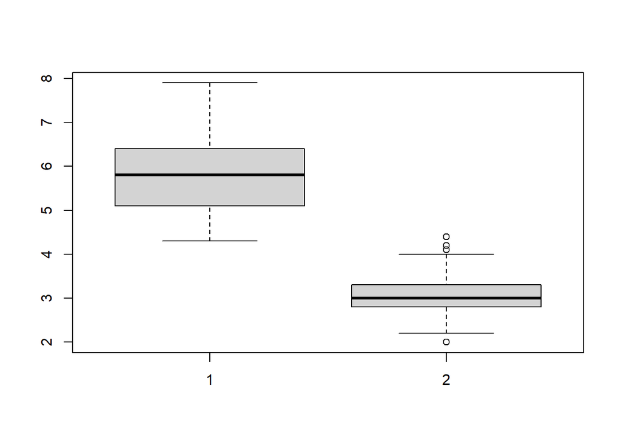

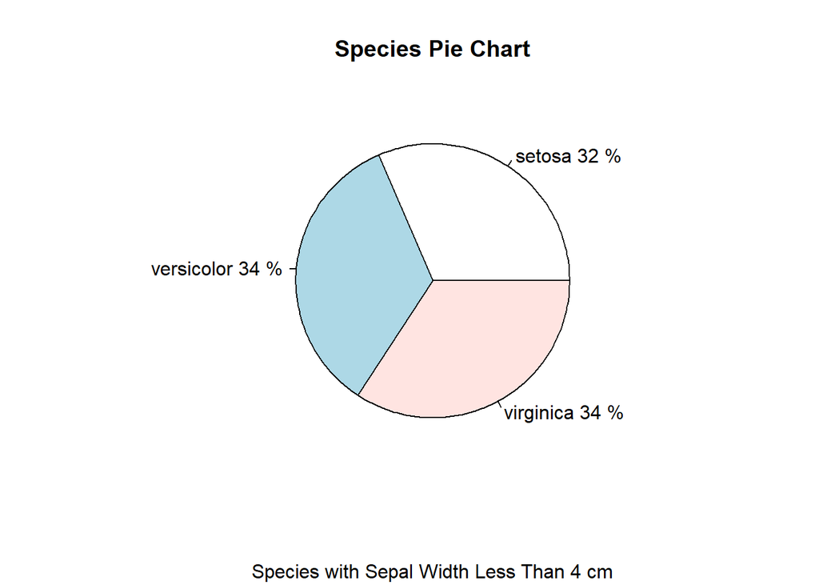